# IE582-Homework4

Hazal Hasret Yurdakul

19 December 2018

**Dataset 2: Attrition Prediction**

**Classification Problem**

Data includes information about employees such as age,education,gender,job satisfaction,and etc. to predict attrition status. Attrition column is target variable and it is binary.

```r
names(attrition_data)
```

```
##  [1] "Age"                      "Attrition"
##  [3] "DailyRate"                "DistanceFromHome"
##  [5] "Education"                "EmployeeCount"
##  [7] "EmployeeNumber"           "EnvironmentSatisfaction"
##  [9] "Gender"                   "HourlyRate"
## [11] "JobInvolvement"           "JobLevel"
## [13] "JobSatisfaction"          "MaritalStatus"
## [15] "MonthlyIncome"            "MonthlyRate"
## [17] "NumCompaniesWorked"       "OverTime"
## [19] "PercentSalaryHike"        "PerformanceRating"
## [21] "RelationshipSatisfaction" "StockOptionLevel"
## [23] "TotalWorkingYears"        "TrainingTimesLastYear"
## [25] "WorkLifeBalance"          "YearsAtCompany"
## [27] "YearsInCurrentRole"       "YearsSinceLastPromotion"
## [29] "YearsWithCurrManager"
```

```r
str(attrition_data)
```

```
## 'data.frame':    1470 obs. of  29 variables:
##  $ Age                     : int  41 49 37 33 27 32 59 30 38 36 ...
##  $ Attrition               : num  1 0 1 0 0 0 0 0 0 0 ...
##  $ DailyRate               : int  1102 279 1373 1392 591 1005 1324 1358 216 1299 ...
##  $ DistanceFromHome        : int  1 8 2 3 2 2 3 24 23 27 ...
##  $ Education               : int  2 1 2 4 1 2 3 1 3 3 ...
##  $ EmployeeCount           : int  1 1 1 1 1 1 1 1 1 1 ...
##  $ EmployeeNumber          : int  1 2 4 5 7 8 10 11 12 13 ...
##  $ EnvironmentSatisfaction : int  2 3 4 4 1 4 3 4 4 3 ...
##  $ Gender                  : num  0 1 1 0 1 1 0 1 1 1 ...
##  $ HourlyRate              : int  94 61 92 56 40 79 81 67 44 94 ...
##  $ JobInvolvement          : int  3 2 2 3 3 3 4 3 2 3 ...
##  $ JobLevel                : int  2 2 1 1 1 1 1 1 3 2 ...
##  $ JobSatisfaction         : int  4 2 3 3 2 4 1 3 3 3 ...
##  $ MaritalStatus           : num  0 1 0 1 1 0 1 0 0 1 ...
##  $ MonthlyIncome           : int  5993 5130 2090 2909 3468 3068 2670 2693 9526 5237 ...
##  $ MonthlyRate             : int  19479 24907 2396 23159 16632 11864 9964 13335 8787 16577 ...
##  $ NumCompaniesWorked      : int  8 1 6 1 9 0 4 1 0 6 ...
##  $ OverTime                : num  1 0 1 1 0 0 1 0 0 0 ...
##  $ PercentSalaryHike       : int  11 23 15 11 12 13 20 22 21 13 ...
##  $ PerformanceRating       : int  3 4 3 3 3 3 4 4 4 3 ...
##  $ RelationshipSatisfaction: int  1 4 2 3 4 3 1 2 2 2 ...
##  $ StockOptionLevel        : int  0 1 0 0 1 0 3 1 0 2 ...
##  $ TotalWorkingYears       : int  8 10 7 8 6 8 12 1 10 17 ...
##  $ TrainingTimesLastYear   : int  0 3 3 3 3 2 3 2 2 3 ...
##  $ WorkLifeBalance         : int  1 3 3 3 3 2 2 3 3 2 ...
##  $ YearsAtCompany          : int  6 10 0 8 2 7 1 1 9 7 ...
##  $ YearsInCurrentRole      : int  4 7 0 7 2 7 0 0 7 7 ...
##  $ YearsSinceLastPromotion : int  0 1 0 3 2 3 0 0 1 7 ...
##  $ YearsWithCurrManager    : int  5 7 0 0 2 6 0 0 8 7 ...
```

```r
dim(attrition_data)
```

```
## [1] 1470   29
```

We can generate train and test data using dataset and classes. 70% of the data is assigned as train data and the remaining instances are placed in test data.

```r
set.seed(123)
smp_size <- floor(0.7 * nrow(attrition_data))

## set the seed to make your partition reproducible
train_ind <- sample(seq_len(nrow(attrition_data)), size = smp_size)

attrition.train <- attrition_data[train_ind, ]
attrition.test <- attrition_data[-train_ind, ]

traindata = attrition.train[, c(1, 3:ncol(attrition.train))]
testdata = attrition.test[, c(1, 3:ncol(attrition.test))]

train.class = attrition.train$Attrition
test.class = attrition.test$Attrition
```

**1-Penalized Regression**

Lasso penalized regression model is performed using “penalized” packgae.optL1 function provides the best lambda value between minlambda and maxlambda paramaters. 10-fold cross validation is performed to choose the best lambda value. Also, since the attrition column is binary, “logistic model” is used. Threshold value is chosen as 0.5 and each instance is classified.

```r
lambda1 <- optL1(train.class, penalized = ~., data = traindata,
    fusedl = FALSE, minlambda1 = 0, maxlambda1 = 2, model = "logistic",
    fold = 10)
```

```
## lambda= 0.763932     12345678910cvl= -367.0779
## lambda= 1.236068     12345678910cvl= -366.5807
## lambda= 1.527864     12345678910cvl= -366.3691
## lambda= 1.708204     12345678910cvl= -366.2956
## lambda= 1.921525     12345678910cvl= -366.2324
## lambda= 1.840043     12345678910cvl= -366.2539
## lambda= 1.890402     12345678910cvl= -366.2402
## lambda= 1.9515   12345678910cvl= -366.2252
## lambda= 1.970025     12345678910cvl= -366.221
## lambda= 1.981474     12345678910cvl= -366.2185
## lambda= 1.988551     12345678910cvl= -366.2169
## lambda= 1.992924     12345678910cvl= -366.216
## lambda= 1.995627     12345678910cvl= -366.2154
## lambda= 1.997297     12345678910cvl= -366.2151
## lambda= 1.99833  12345678910cvl= -366.2154
## lambda= 1.996983     12345678910cvl= -366.2152
## lambda= 1.997657     12345678910cvl= -366.2154
```

```r
pen <- penalized(train.class, penalized = ~., data = traindata,
    lambda1 = lambda1$lambda, model = "logistic", fusedl = FALSE)
```

[output not shown]

[output cut: 140 more lines]

[output not shown]

```r
pen
```

```
## Penalized logistic regression object
## 29 regression coefficients of which 25 are non-zero
##
## Loglikelihood =   -335.3955
## L1 penalty =  9.417887   at lambda1 =  1.997297
```

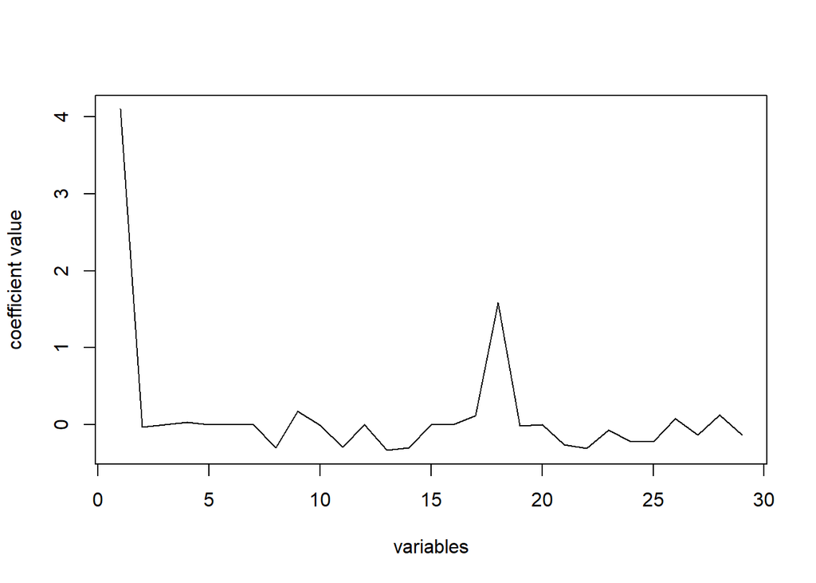

```r
plot(coefficients(pen, "all"), type = "l", xlab = "variables",
    ylab = "coefficient value")
```

```r
prediction = predict(pen, penalized = traindata)

for (i in 1:length(prediction)) {
    if (prediction[i] < 0.5) {
        prediction[i] = 0
    } else {
        prediction[i] = 1
    }
}
confusionMatrix(factor(train.class), factor(prediction))
```

```
## Confusion Matrix and Statistics
##
##           Reference
## Prediction   0   1
##          0 855  14
##          1 117  43
##
##                Accuracy : 0.8727
##                  95% CI : (0.8508, 0.8925)
##     No Information Rate : 0.9446
##     P-Value [Acc > NIR] : 1
##
##                   Kappa : 0.3426
##  Mcnemar's Test P-Value : <2e-16
##
##             Sensitivity : 0.8796
##             Specificity : 0.7544
##          Pos Pred Value : 0.9839
##          Neg Pred Value : 0.2687
##              Prevalence : 0.9446
##          Detection Rate : 0.8309
##    Detection Prevalence : 0.8445
##       Balanced Accuracy : 0.8170
##
##        'Positive' Class : 0
##
```

```r
prediction.test = predict(pen, penalized = testdata)
for (i in 1:length(prediction.test)) {
    if (prediction.test[i] < 0.5) {
        prediction.test[i] = 0
    } else {
        prediction.test[i] = 1
    }
}

confusionMatrix(factor(test.class), factor(prediction.test))
```

```
## Confusion Matrix and Statistics
##
##           Reference
## Prediction   0   1
##          0 359   5
##          1  52  25
##
##                Accuracy : 0.8707
##                  95% CI : (0.8358, 0.9006)
##     No Information Rate : 0.932
##     P-Value [Acc > NIR] : 1
##
##                   Kappa : 0.4095
##  Mcnemar's Test P-Value : 1.109e-09
##
##             Sensitivity : 0.8735
##             Specificity : 0.8333
##          Pos Pred Value : 0.9863
##          Neg Pred Value : 0.3247
##              Prevalence : 0.9320
##          Detection Rate : 0.8141
##    Detection Prevalence : 0.8254
##       Balanced Accuracy : 0.8534
##
##        'Positive' Class : 0
##
```

As you can see, accuracy of train and test data are similar, about 87%. Also 25 regression coefficients out of 29 coefficients are used to generate the penalized lasso model.

**2-Decision Tree**

```r
library(rpart)
library(rattle)
```

```r
library(rpart.plot)
library(caret)
library(data.table)

traindata = data.table(traindata)
trials <- expand.grid(minsplit_values = c(10, 15, 20, 25, 50),
    cp_values = c(0.005, 0.001, 0.01))

for (i in 1:nrow(trials)) {
    tree <- rpart(train.class ~ ., data = traindata, method = "class",
        control = rpart.control(cp = trials$cp_values[i], minsplit = trials$minsplit_values[i]))
    cv_error <- tree$cptable[which.min(tree$cptable[, "xerror"]),
        "xerror"]
    conf.mat = confusionMatrix(as.factor(train.class), predict(tree,
        type = "class"))
    print(paste0("cv_error=", cv_error, " accuracy=", unname(conf.mat$overall[1]),
        " cp=", trials$cp_values[i], " minsplit=", trials$minsplit_values[i]))
}
```

```
## [1] "cv_error=1 accuracy=0.920310981535471 cp=0.005 minsplit=10"
## [1] "cv_error=0.975 accuracy=0.910592808551992 cp=0.005 minsplit=15"
## [1] "cv_error=1 accuracy=0.896987366375121 cp=0.005 minsplit=20"
## [1] "cv_error=1 accuracy=0.886297376093295 cp=0.005 minsplit=25"
## [1] "cv_error=1 accuracy=0.870748299319728 cp=0.005 minsplit=50"
## [1] "cv_error=1 accuracy=0.931972789115646 cp=0.001 minsplit=10"
## [1] "cv_error=1 accuracy=0.912536443148688 cp=0.001 minsplit=15"
## [1] "cv_error=1 accuracy=0.897959183673469 cp=0.001 minsplit=20"
## [1] "cv_error=0.95625 accuracy=0.886297376093295 cp=0.001 minsplit=25"
## [1] "cv_error=1 accuracy=0.870748299319728 cp=0.001 minsplit=50"
## [1] "cv_error=0.95625 accuracy=0.900874635568513 cp=0.01 minsplit=10"
## [1] "cv_error=1 accuracy=0.896987366375121 cp=0.01 minsplit=15"
## [1] "cv_error=0.9875 accuracy=0.894071914480078 cp=0.01 minsplit=20"
## [1] "cv_error=0.99375 accuracy=0.886297376093295 cp=0.01 minsplit=25"
## [1] "cv_error=1 accuracy=0.870748299319728 cp=0.01 minsplit=50"
```

```r
tree <- rpart(train.class ~ ., data = traindata, method = "class",
    control = rpart.control(cp = 0.005, minsplit = 15))
tree
```

```
## n= 1029
##
## node), split, n, loss, yval, (yprob)
##       * denotes terminal node
##
##   1) root 1029 160 0 (0.84450923 0.15549077)
##     2) OverTime< 0.5 733  71 0 (0.90313779 0.09686221)
##       4) TotalWorkingYears>=2.5 672  51 0 (0.92410714 0.07589286)
##         8) YearsSinceLastPromotion< 14.5 666  48 0 (0.92792793 0.07207207)
##          16) DailyRate>=409 522  28 0 (0.94636015 0.05363985) *
##          17) DailyRate< 409 144  20 0 (0.86111111 0.13888889)
##            34) MonthlyRate< 25451.5 138  16 0 (0.88405797 0.11594203)
##              68) DistanceFromHome< 22.5 117   8 0 (0.93162393 0.06837607) *
##              69) DistanceFromHome>=22.5 21   8 0 (0.61904762 0.38095238)
##               138) Age>=30.5 16   3 0 (0.81250000 0.18750000)
##                 276) TotalWorkingYears>=7.5 11   0 0 (1.00000000 0.00000000) *
##                 277) TotalWorkingYears< 7.5 5   2 1 (0.40000000 0.60000000) *
##               139) Age< 30.5 5   0 1 (0.00000000 1.00000000) *
##            35) MonthlyRate>=25451.5 6   2 1 (0.33333333 0.66666667) *
##         9) YearsSinceLastPromotion>=14.5 6   3 0 (0.50000000 0.50000000) *
##       5) TotalWorkingYears< 2.5 61  20 0 (0.67213115 0.32786885)
##        10) HourlyRate>=60.5 43   9 0 (0.79069767 0.20930233)
##          20) JobSatisfaction>=1.5 36   5 0 (0.86111111 0.13888889) *
##          21) JobSatisfaction< 1.5 7   3 1 (0.42857143 0.57142857) *
##        11) HourlyRate< 60.5 18   7 1 (0.38888889 0.61111111)
##          22) JobInvolvement>=2.5 12   5 0 (0.58333333 0.41666667) *
##          23) JobInvolvement< 2.5 6   0 1 (0.00000000 1.00000000) *
##     3) OverTime>=0.5 296  89 0 (0.69932432 0.30067568)
##       6) MonthlyIncome>=3745 201  35 0 (0.82587065 0.17412935)
##        12) StockOptionLevel>=0.5 116  11 0 (0.90517241 0.09482759)
##          24) DailyRate>=766.5 57   1 0 (0.98245614 0.01754386) *
##          25) DailyRate< 766.5 59  10 0 (0.83050847 0.16949153)
##            50) YearsInCurrentRole>=4.5 27   1 0 (0.96296296 0.03703704) *
##            51) YearsInCurrentRole< 4.5 32   9 0 (0.71875000 0.28125000)
##             102) HourlyRate>=72.5 17   2 0 (0.88235294 0.11764706) *
##             103) HourlyRate< 72.5 15   7 0 (0.53333333 0.46666667)
##               206) RelationshipSatisfaction>=2.5 9   2 0 (0.77777778 0.22222222) *
##               207) RelationshipSatisfaction< 2.5 6   1 1 (0.16666667 0.83333333) *
##        13) StockOptionLevel< 0.5 85  24 0 (0.71764706 0.28235294)
##          26) TrainingTimesLastYear>=1.5 75  17 0 (0.77333333 0.22666667)
##            52) PercentSalaryHike< 21.5 68  12 0 (0.82352941 0.17647059)
##             104) NumCompaniesWorked< 5.5 53   5 0 (0.90566038 0.09433962) *
##             105) NumCompaniesWorked>=5.5 15   7 0 (0.53333333 0.46666667)
##               210) Gender< 0.5 7   0 0 (1.00000000 0.00000000) *
##               211) Gender>=0.5 8   1 1 (0.12500000 0.87500000) *
##            53) PercentSalaryHike>=21.5 7   2 1 (0.28571429 0.71428571) *
##          27) TrainingTimesLastYear< 1.5 10   3 1 (0.30000000 0.70000000) *
##       7) MonthlyIncome< 3745 95  41 1 (0.43157895 0.56842105)
##        14) YearsInCurrentRole>=1.5 61  28 0 (0.54098361 0.45901639)
##          28) HourlyRate< 85.5 52  20 0 (0.61538462 0.38461538)
##            56) EnvironmentSatisfaction>=1.5 43  13 0 (0.69767442 0.30232558)
##             112) MaritalStatus>=0.5 16   1 0 (0.93750000 0.06250000) *
##             113) MaritalStatus< 0.5 27  12 0 (0.55555556 0.44444444)
##               226) MonthlyIncome< 2671.5 14   3 0 (0.78571429 0.21428571) *
##               227) MonthlyIncome>=2671.5 13   4 1 (0.30769231 0.69230769) *
##            57) EnvironmentSatisfaction< 1.5 9   2 1 (0.22222222 0.77777778) *
##          29) HourlyRate>=85.5 9   1 1 (0.11111111 0.88888889) *
##        15) YearsInCurrentRole< 1.5 34   8 1 (0.23529412 0.76470588)
##          30) MonthlyIncome>=2930.5 7   3 0 (0.57142857 0.42857143) *
##          31) MonthlyIncome< 2930.5 27   4 1 (0.14814815 0.85185185) *
```

```r
printcp(tree)  #display cp table
```

```
##
## Classification tree:
## rpart(formula = train.class ~ ., data = traindata, method = "class",
##     control = rpart.control(cp = 0.005, minsplit = 15))
##
## Variables actually used in tree construction:
##  [1] Age                      DailyRate
##  [3] DistanceFromHome         EnvironmentSatisfaction
##  [5] Gender                   HourlyRate
##  [7] JobInvolvement           JobSatisfaction
##  [9] MaritalStatus            MonthlyIncome
## [11] MonthlyRate              NumCompaniesWorked
## [13] OverTime                 PercentSalaryHike
## [15] RelationshipSatisfaction StockOptionLevel
## [17] TotalWorkingYears        TrainingTimesLastYear
## [19] YearsInCurrentRole       YearsSinceLastPromotion
##
## Root node error: 160/1029 = 0.15549
##
## n= 1029
##
##         CP nsplit rel error xerror     xstd
## 1 0.040625      0   1.00000 1.0000 0.072651
## 2 0.037500      2   0.91875 1.0375 0.073745
## 3 0.031250      4   0.84375 1.0063 0.072836
## 4 0.015625      5   0.81250 1.0000 0.072651
## 5 0.012500      7   0.78125 1.0625 0.074455
## 6 0.008750     15   0.66250 1.1188 0.075999
## 7 0.006250     20   0.61875 1.1687 0.077312
## 8 0.005000     27   0.57500 1.2188 0.078573
```

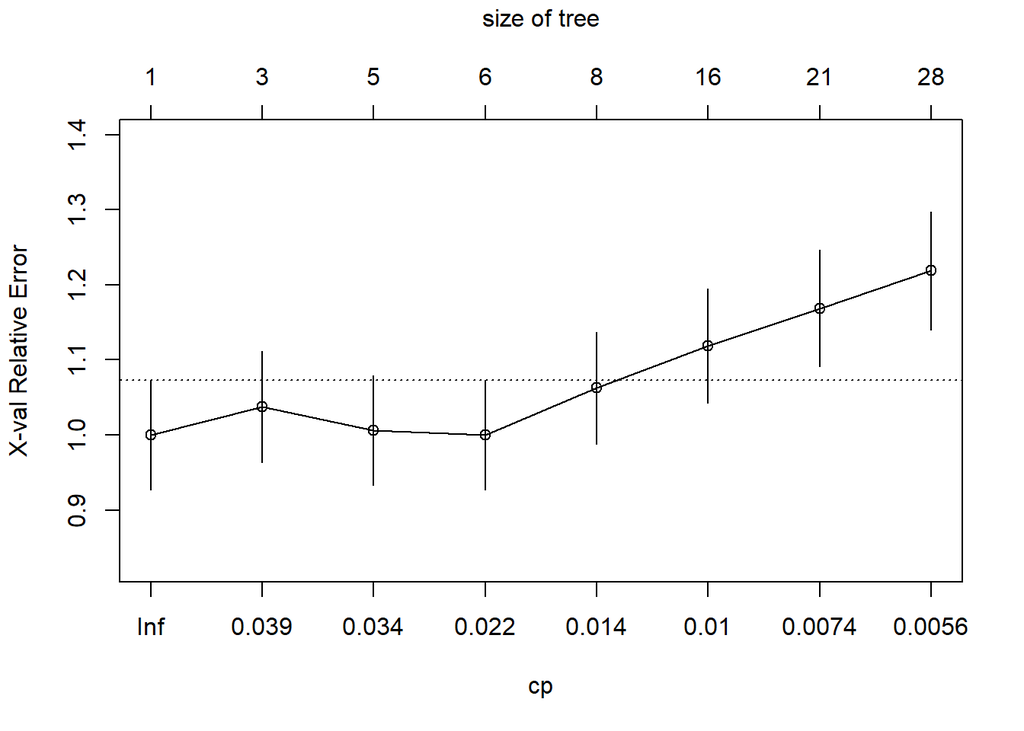

```r
plotcp(tree)
```